# 2020 NFL Penalty Analysis

## Kael Lenus

[figure not shown]

## Introduction

The NFL is a highly competitive league and extremely exciting as a result. There are so many aspects of the game that provide intrigue from the games, players, front offices, **refs**, and fans. The league can manufacture drama into almost anything (as I write this they are literally about to televise a schedule release), so there's no wonder that it is the most popular sport in the U.S. There is also a lot of analytics involved with the NFL, from internal team analytics that are used when making decisions to public analytics that are used for journalism and things like fantasy football. There are a lot of different aspects that you can focus on in football and there's usually a lot of information to be found concerning those areas. Except, I've always felt that no one really talks about penalties that much. Sure, fans complain about refs incessantly and blame them for all their and their team's problems, but I've never really seen penatlies examined in an in depth way. That's what this tutorial is going to be about (I can't promise it will be deep but I'll try my best), looking at penalties and asking pertinent questions about them. The two questions I will be mainly concerned with are: (1) Is there any correlation between a team being good and penalties being favorable to them? (2) Do pass-heavy offenses get helped by penalties more?

## Data Collection

The data I am going to use for this tutorial is going to come from [nflfastpy](https://pypi.org/project/nflfastpy/), a Python package for loading NFL play by play data, schedule data, roster data, and team logo data from [nflfastR](https://www.nflfastr.com/). nflfastR is itself a package for scraping NFL data, but because it's made for R, I need to use nflfastpy as a wrapper to access the data. Thankfully, loading the pbp (play by play) data into a data frame is pretty simple and does not require any cleaning or tidying. There's a wealth of information available in the pbp data, but I'll only be focusing on a few values that are most pertinent to our analysis.

```python
!pip install nflfastpy
import nflfastpy
import pandas as pd
import matplotlib.pyplot as plt
import collections
from statistics import mean
from sklearn import linear_model
import numpy as np

pd.set_option('display.max_rows', None)
pd.set_option('display.max_columns', None)
pd.set_option('display.width', None)
pd.set_option('display.max_colwidth', None)

#looking at the 2020 season for now
df = nflfastpy.load_pbp_data(year=2020)
#roster_df = nflfastpy.load_roster_data(year=2020)
team_logo_df = nflfastpy.load_team_logo_data()
```

What I'm doing below is creating two data frames that hold information I'm interested in. pen_df is just all the plays in the 2020 NFL season where a penalty occured. pen_noplay_df is all plays where the penalty was all that occured in the play (i.e., it's not a play where the penalty was added on to the play that happened). I'll explain the reason for pen_noplay_df later. Also, if you're unfamiliar with the NFL or penalties in the NFL, it could be useful to [brush up on them.](https://howtheyplay.com/team-sports/Football-Penalties-Explained)

```python
#this list has column values that I am interested in
lst = [
'season_type',
'play_id',
'play_type',
'home_team',
'away_team',
'posteam',
'defteam',
# 'home_wp',
# 'away_wp',
 'epa',
 'wpa',
'penalty',
'penalty_type',
'penalty_team',
 'penalty_player_name',
 'penalty_yards',
   'desc'
]
#pen_df has all plays in the 2020 regular season where a penalty occurred
pen_df = df[lst].loc[df['penalty'] == 1].loc[df['season_type'] == 'REG']
pen_df['no_play'] = [1 if str(x).endswith('No Play.') else 0 for x in pen_df['desc'].tolist()]
#pen_noplay_df has all plays in the 2020 season where a penalty occurred and there was no play
pen_noplay_df = pen_df[lst+['no_play']].loc[pen_df['no_play'] == 1]
pen_noplay_df.head()
```

|  | season_type | play_id | play_type | home_team | away_team | posteam | defteam | epa | wpa | penalty | penalty_type | penalty_team | penalty_player_name | penalty_yards | desc | no_play |
| --- | --- | --- | --- | --- | --- | --- | --- | --- | --- | --- | --- | --- | --- | --- | --- | --- |
| 46 | REG | 1205 | no_play | SF | ARI | SF | ARI | -0.697016 | -0.024852 | 1.0 | False Start | SF | G.Kittle | 5.0 | (14:22) (Shotgun) PENALTY on SF-85-G.Kittle, False Start, 5 yards, enforced at ARI 7 - No Play. | 1 |
| 73 | REG | 1860 | no_play | SF | ARI | ARI | SF | -0.431990 | -0.017927 | 1.0 | False Start | ARI | J.Pugh | 5.0 | (3:01) (No Huddle, Shotgun) PENALTY on ARI-67-J.Pugh, False Start, 5 yards, enforced at ARI 42 - No Play. | 1 |
| 94 | REG | 2343 | no_play | SF | ARI | ARI | SF | -0.875106 | -0.041535 | 1.0 | Offensive Holding | ARI | D.Daniels | 10.0 | (14:55) (Shotgun) 13-C.Kirk left end to ARI 40 for 3 yards (57-D.Greenlaw). PENALTY on ARI-81-D.Daniels, Offensive Holding, 10 yards, enforced at ARI 37 - No Play. | 1 |
| 100 | REG | 2509 | no_play | SF | ARI | ARI | SF | -0.450131 | -0.018775 | 1.0 | False Start | ARI | K.Drake | 5.0 | (11:52) (Shotgun) PENALTY on ARI-41-K.Drake, False Start, 5 yards, enforced at ARI 49 - No Play. | 1 |
| 129 | REG | 3204 | no_play | SF | ARI | ARI | SF | 1.440474 | 0.061158 | 1.0 | Defensive Holding | SF | K.Williams | 5.0 | (1:37) (No Huddle, Shotgun) 1-K.Murray pass incomplete deep right. PENALTY on SF-24-K.Williams, Defensive Holding, 5 yards, enforced at ARI 6 - No Play. | 1 |

## Exploratory Data Analysis

So the first question I want to ask is: Which teams got hit the hardest by penalties in 2020 and also which teams benefited from them the most? The first thing we can do to answer that question is just to add up the penalty yardage for and against for each team and graph it.

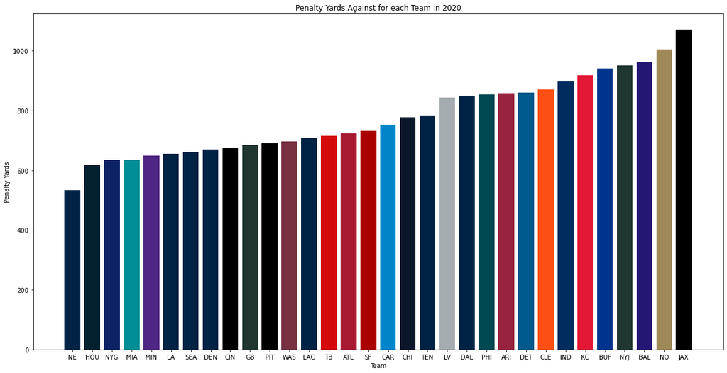

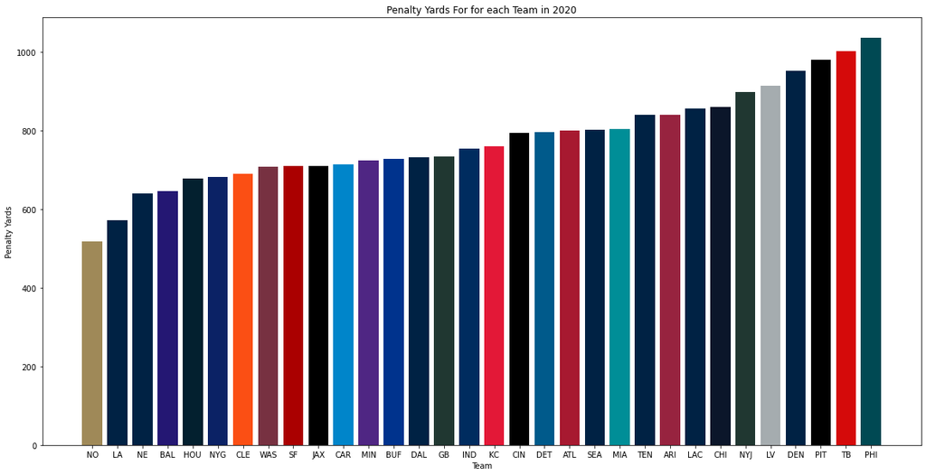

```python
#team colors
team_colors_map = dict(zip(team_logo_df['team_abbr'].tolist(),team_logo_df['team_color'].tolist()))
#Find the total penalty yards for each team
pen_yards_ag = {}
pen_yards_for = {}
for index, row in pen_df.iterrows():
    if row['penalty_team'] in pen_yards_ag:
        pen_yards_ag[row['penalty_team']] +=  row['penalty_yards']
    else:
        pen_yards_ag[row['penalty_team']] =  row['penalty_yards']

    if row['penalty_team'] == row['home_team']:
        ben_team = row['away_team']
    else:
        ben_team = row['home_team']

    if ben_team in pen_yards_for:
        pen_yards_for[ben_team] +=  row['penalty_yards']
    else:
        pen_yards_for[ben_team] =  row['penalty_yards']

pen_yards_ag = dict(sorted(pen_yards_ag.items(), key=lambda x: x[1]))
x_pos = [i for i, _ in enumerate(pen_yards_ag.keys())]
colors = [team_colors_map[x] for x in pen_yards_ag.keys()]
plt.figure(figsize=(20,10))
plt.bar(x_pos, pen_yards_ag.values(), color=colors, tick_label=list(pen_yards_ag.keys()))
plt.xlabel("Team")
plt.ylabel("Penalty Yards")
plt.title("Penalty Yards Against for each Team in 2020")
plt.show()

pen_yards_for = dict(sorted(pen_yards_for.items(), key=lambda x: x[1]))
x_pos = [i for i, _ in enumerate(pen_yards_for.keys())]
colors = [team_colors_map[x] for x in pen_yards_for.keys()]
plt.figure(figsize=(20,10))
plt.bar(x_pos, pen_yards_for.values(), color=colors, tick_label=list(pen_yards_for.keys()))
plt.xlabel("Team")
plt.ylabel("Penalty Yards")
plt.title("Penalty Yards For for each Team in 2020")
plt.show()
```

So this is interesting, especially as a Ravens fan. Before I saw this chart I would have definitely said that the Ravens were particularly hard done by penalties in 2020, and this seems to confirm that. The Saints would also feel like the refs were unfair to them. Another team that is interesting here are the Patriots in that the are Bottom 5 in both penalty yards for and against.

Let's see how these teams do when graphing Penalty Yards For vs Penalty Yards Against.

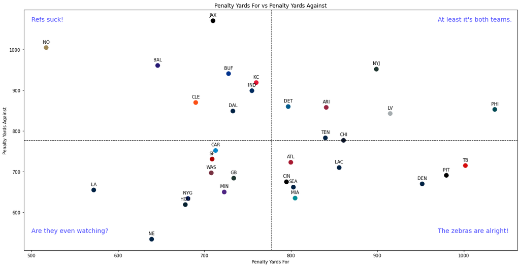

```python
#graphing penalty yards for vs penalty yards against
odx = collections.OrderedDict(sorted(pen_yards_for.items()))
ody = collections.OrderedDict(sorted(pen_yards_ag.items()))
oteams = list(odx.keys())

plt.figure(figsize=(20,10))
plt.scatter(odx.values(), ody.values(), c=[team_colors_map[t] for t in oteams], marker='o', s=90)
plt.xlabel("Penalty Yards For")
plt.ylabel("Penalty Yards Against")
plt.title("Penalty Yards For vs Penalty Yards Against")

i = 0
for xval,yval in zip(odx.values(), ody.values()):
    plt.annotate(oteams[i], (xval, yval), textcoords="offset points", xytext=(0,10), ha='center')
    i += 1
plt.axhline(y=mean(ody.values()), color='k', linestyle='--', linewidth=1)
plt.axvline(x=mean(odx.values()), color='k',linestyle='--', linewidth=1)
plt.text(x=500, y=550, s="Are they even watching?",alpha=0.7,fontsize=14, color='b')
plt.text(x=500, y=1070, s="Refs suck!",alpha=0.7,fontsize=14, color='b')
plt.text(x=970, y=1070, s="At least it's both teams.", alpha=0.7,fontsize=14, color='b')
plt.text(x=970, y=550, s="The zebras are alright!", alpha=0.7,fontsize=14, color='b')
plt.show()
```

One of the interesting teams here is Tampa Bay (Super Bowl champions), who were near the top in penalty yards for and below average for penalty yards against. Again, Baltimore is firmly in the "Refs suck!" category which definitely passes the eye test.

## Do good teams get more penalties to go their way?

Seeing this chart leads to another question: is there any correlation between penalty yards and winning percentage? To answer this let's chart net penalty yards (Penalty Yards For - Penalty Yards Against) vs Win Pct.

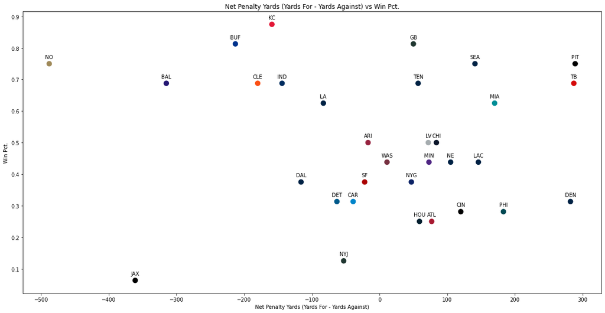

```python
#just going to hard code in the 2020 win percentages
pcts = [
    .500,
    .250,
    .688,
    .813,
    .313,
    .500,
    .281,
    .688,
    .375,
    .313,
    .313,
    .813,
    .250,
    .688,
    .063,
    .875,
    .625,
    .438,
    .500,
    .625,
    .438,
    .438,
    .750,
    .375,
    .125,
    .281,
    .750,
    .750,
    .375,
    .688,
    .688,
    .438
]
win_pcts = dict(zip(oteams, pcts))
#plotting net penalty yards vs win pct.
plt.figure(figsize=(20,10))
net_yards = [i-j for i,j in zip(odx.values(),ody.values())]
plt.scatter(net_yards, win_pcts.values(), c=[team_colors_map[t] for t in oteams], marker='o', s=90)
plt.xlabel("Net Penalty Yards (Yards For - Yards Against)")
plt.ylabel("Win Pct.")
plt.title("Net Penalty Yards (Yards For - Yards Against) vs Win Pct.")

i = 0
for xval,yval in zip(net_yards, win_pcts.values()):
    plt.annotate(oteams[i], (xval, yval), textcoords="offset points", xytext=(0,10), ha='center')
    i += 1
plt.show()
```

There doesn't really appear to be a correlation between net penalty yards and win percentage, at least not a linear one. Looking at the playoff teams (mostly teams above .600) in particular, you can see that they are pretty well spread out in terms of net penalty yards. So whether you're being helped by penalties, or hurt by them, or neither, it doesn't realy affect your chances of winning. However there is a problem with this analysis, and just using raw penalty yards in general.

## The problem with raw penalty yards

When you're watching a game, you'll often see a graphic like this:

[figure not shown]

Now, while this can definitely be informative (and this graphic in particular was an apt depiction of the impact penalties had in the game), that isn't always the case. In fact, my motivation for looking at penalties was exactly because of graphics like this. I would be watching a game and see that the two teams had a similar amount of penalties and/or penalty yards, and think to myself, "But that really doesn't do a good job of capturing the impact of those penalties."

To illustrate this let me pose a question: Would you rather have a 5 yard definsive holding penalty against you or a 50 yard defensive pass interference against you? Both result in an automatic first down for the opposing offense, it's just that one is 45 yards further down the field than the other. The intuitive answer seems to be that you would take the 5 yard penalty, and in some (and maybe most) instances you would be correct. But the idea that I'm trying to get at is that the impact of a penalty is largely dependent on the circumstances wherein which it occurs. Let's say that 50 yard DPI was early in the first quarter of a game; it would still be bad but not something you couldn't recover from. Let's also say that the 5 yard defensive holding occured in the same game on a 4th and goal with 1 minute to go in a one score game; this would likely lose you the game. Yet, if you just looked at the raw penalty yards you would think that the DPI was 10x worse than the holding penalty. So what I want to do is find a better way to evaluate the impact that penalties have on games.

## WPA and EPA

These are the two metrics I'm going to use to try to get a better idea of the impact of penalties.

### What is WPA?

[WPA](https://www.advancedfootballanalytics.com/index.php/home/stats/stats-explained/win-probability-and-wpa) stands for Win Probability Added, and is a fairly simple concept to understand (at a high level). Before any play both teams will have a Win Probability, the percentage chance that they will win the game. WPA is just the difference between the win probability before a play happens and the win probability after a play. The win probability model that nflfastR uses factors in features like the seconds remaining in a half/game, yard line, score differential, down and distance, etc. It's clear that evalutaing win probability added after a penalty will provide a more complete picture than just using raw penalty yards.

### What is EPA?

EPA stands for expected points added. Like WPA is based on Win Probability, EPA is based on Expected Points. Expected Points is a bit more of an abstract concept than Win Probability, but it essentially is a measure of the net points a team can expect to gain from a particular combination of down, distance, and field position. EPA is just the difference between EP before and after a play, just like with WPA.

## Evaluating the impacts of penalties using WPA and EPA

So what I'm going to do is try to see how penalties affect different teams' WPA and EPA, and hope that provides a more accurate picture than raw penalty yards. However, there is a problem. On certain plays where a penalty occurred it's hard to get the WPA or EPA of the penalty alone. Let me show you an example:

```python
pen_df.head(1)
```

|  | season_type | play_id | play_type | home_team | away_team | posteam | defteam | epa | wpa | penalty | penalty_type | penalty_team | penalty_player_name | penalty_yards | desc | no_play |
| --- | --- | --- | --- | --- | --- | --- | --- | --- | --- | --- | --- | --- | --- | --- | --- | --- |
| 2 | REG | 54 | pass | SF | ARI | SF | ARI | 1.294838 | 0.033715 | 1.0 | Horse Collar Tackle | ARI | I.Simmons | 15.0 | (15:00) (Shotgun) 10-J.Garoppolo pass short right to 85-G.Kittle to SF 30 for 5 yards (48-I.Simmons). PENALTY on ARI-48-I.Simmons, Horse Collar Tackle, 15 yards, enforced at SF 30. Caught at SF29. 1-Y… | 0 |

This was a 5 yard pass play with a 15 yard Horse Collar penalty tacked on. Unfortunately, there is no way to determine the amount of the WPA and EPA that came from the play and the penalty (At least not with the data available). Because of this, for the following analysis I decided to just not consider any plays where a play occurred and the penalty was added on. I made another data frame called pen_noplay_df which is all the plays where no actual play occured and the only thing there was in the play was a penalty. This way I can just evaluate the effects of penalties on their own.

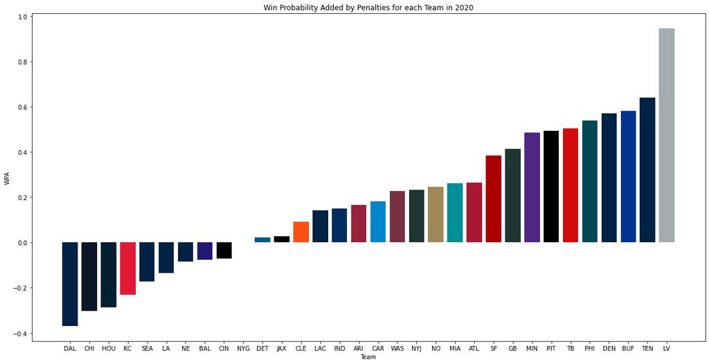

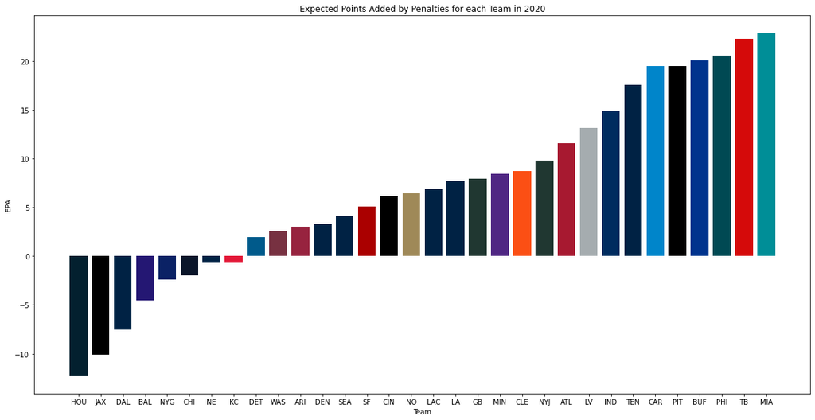

```python
wpa = {}
epa = {}
pen_noplay_count = {}
#calculating cumulative wpa and epa for each team on each no-play penalty
for index, row in pen_noplay_df.iterrows():
    if row['penalty_team'] == row['home_team']:
        ben_team = row['away_team']
    else:
        ben_team = row['home_team']

    if str(row['wpa']) != 'nan' and str(row['epa']) != 'nan':
        #if ben_team in pen_noplay_count:
        #    pen_noplay_count[ben_team] +=  1
        #else:
        #    pen_noplay_count[ben_team] =  1

        if ben_team in wpa:
            wpa[ben_team] +=  row['wpa']
        else:
            wpa[ben_team] =  row['wpa']

        if ben_team in epa:
            epa[ben_team] +=  row['epa']
        else:
            epa[ben_team] =  row['epa']

#graphing WPA for each team
wpa = dict(sorted(wpa.items(), key=lambda x: x[1]))
x_pos = [i for i, _ in enumerate(wpa.keys())]
colors = [team_colors_map[x] for x in wpa.keys()]
plt.figure(figsize=(20,10))
plt.bar(x_pos, wpa.values(), color=colors, tick_label=list(wpa.keys()))
plt.xlabel("Team")
plt.ylabel("WPA")
plt.title("Win Probability Added by Penalties for each Team in 2020")
plt.show()

#graphing EPA for each team
epa = dict(sorted(epa.items(), key=lambda x: x[1]))
x_pos = [i for i, _ in enumerate(epa.keys())]
colors = [team_colors_map[x] for x in epa.keys()]
plt.figure(figsize=(20,10))
plt.bar(x_pos, epa.values(), color=colors, tick_label=list(epa.keys()))
plt.xlabel("Team")
plt.ylabel("EPA")
plt.title("Expected Points Added by Penalties for each Team in 2020")
plt.show()
```

So this should provide us (hopefully) a more accurate look at which teams benefitted the most from penalties. It's also interesting to compare penalties based on the two metrics. There are a lot of differences between the two, but none of them seem to be that major. For instance, there is no team that was really benefitted by penalties according to WPA who was really hurt by them according to EPA. Let's graph each of these metrics versus win percentage to see if there's any correlation.

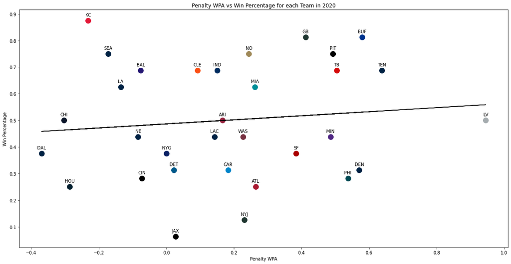

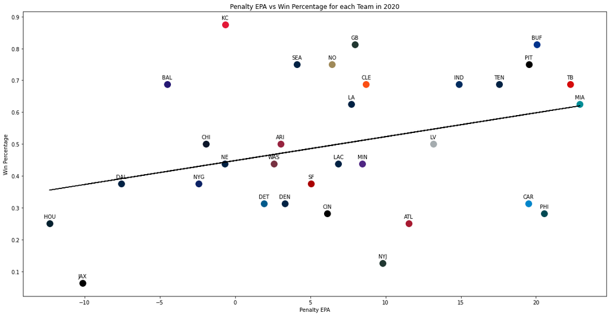

```python
#graphing penalty wpa vs win pct for each team, with regression line
lm = linear_model.LinearRegression()
arr_wpa_vals = []
arr_win_pcts = []
plt.figure(figsize=(20,10))
plt.xlabel("Penalty WPA")
plt.ylabel("Win Percentage")
plt.title("Penalty WPA vs Win Percentage for each Team in 2020")
for team,pct in win_pcts.items():
    plt.plot(wpa[team], pct, color=team_colors_map[team], marker='o',markersize=12)
    plt.annotate(team, (wpa[team], pct), textcoords="offset points", xytext=(0,10), ha='center')
    arr_wpa_vals.append(wpa[team])
    arr_win_pcts.append(pct)
arr_wpa_vals = np.array(arr_wpa_vals)
arr_win_pcts = np.array(arr_win_pcts)
lm.fit(arr_wpa_vals.reshape(-1,1), arr_win_pcts.reshape(-1,1))
y_pred = lm.predict(arr_wpa_vals.reshape(-1,1))
plt.plot(arr_wpa_vals, y_pred, '-', color='black')
plt.show()

#graphing penalty epa vs win pct for each team, with regression line
lm2 = linear_model.LinearRegression()
arr_epa_vals = []
arr_win_pcts = []
plt.figure(figsize=(20,10))
plt.xlabel("Penalty EPA")
plt.ylabel("Win Percentage")
plt.title("Penalty EPA vs Win Percentage for each Team in 2020")
for team,pct in win_pcts.items():
    plt.plot(epa[team], pct, color=team_colors_map[team], marker='o',markersize=12)
    plt.annotate(team, (epa[team], pct), textcoords="offset points", xytext=(0,10), ha='center')
    arr_epa_vals.append(epa[team])
    arr_win_pcts.append(pct)
arr_epa_vals = np.array(arr_epa_vals)
arr_win_pcts = np.array(arr_win_pcts)
lm2.fit(arr_epa_vals.reshape(-1,1), arr_win_pcts.reshape(-1,1))
y_pred = lm2.predict(arr_epa_vals.reshape(-1,1))
plt.plot(arr_epa_vals, y_pred, color='black')
plt.show()
```

Even when using WPA and EPA there really does not appear to be a linear correlation between benefitting from penalties and win percentage. So the answer to our first question is no, good teams don't get help from the referees.

## Do pass heavy teams get helped more by penalties?

So we seem to have determined that good teams don't appear to get any extra benefits from penalties. But do pass heavy teams? I must admit, this question is based on nothing but observation and speculation on my part. I've always felt that pass heavy teams get helped more by penalties than run heavy teams. Let's see if that's the case by graphing pass attempts vs penalty WPA and EPA.

```python
passes = {}
passing_epa = {}
rushes = {}
#Getting pass attempts, passing epa (to get passing epa/play), rush attempts (didn't use ultimately)
for index, row in df.iterrows():
    if row['play_type'] == 'pass':
        if row['penalty'] != 1:
            if row['posteam'] not in passes:
                passes[row['posteam']] = 0
            else:
                passes[row['posteam']] += 1

        if str(row['epa']) != 'nan' and row['penalty'] != 1:
            if row['posteam'] not in passing_epa:
                passing_epa[row['posteam']] = row['epa']
            else:
                passing_epa[row['posteam']] += row['epa']

    if row['play_type'] == 'run':
        if row['posteam'] not in rushes:
            rushes[row['posteam']] = 0
        else:
            rushes[row['posteam']] += 1
passes = dict(sorted(passes.items(), key=lambda x: x[1]))
passing_epa_per_play = dict(zip(passes.keys(),[passing_epa[t]/a for t,a in passes.items()]))
passing_epa_per_play = dict(sorted(passing_epa_per_play.items(), key=lambda x: x[1]))
rushes = dict(sorted(rushes.items(), key=lambda x: x[1]))
#print(passes)
#print(passing_epa_per_play)
```

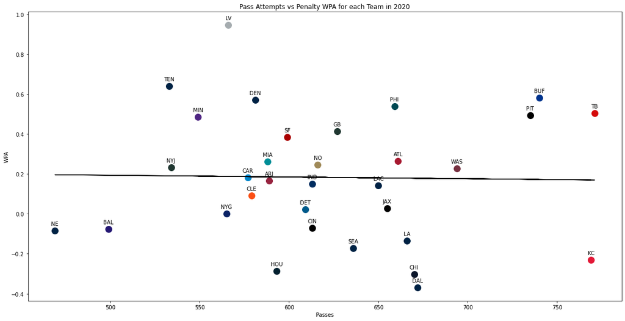

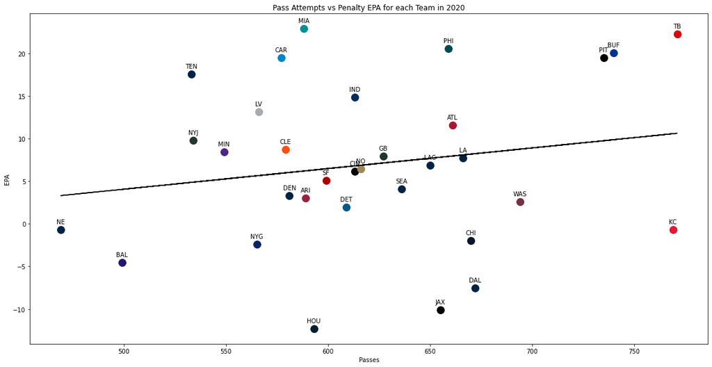

```python
#graphing pass attempts vs penalty wpa for each team, with regression line
lm = linear_model.LinearRegression()
arr_x_vals = []
arr_y_vals = []
plt.figure(figsize=(20,10))
plt.xlabel("Passes")
plt.ylabel("WPA")
plt.title("Pass Attempts vs Penalty WPA for each Team in 2020")
for team,wpa_val in wpa.items():
    plt.plot(passes[team], wpa_val, color=team_colors_map[team], marker='o',markersize=12)
    plt.annotate(team, (passes[team], wpa_val), textcoords="offset points", xytext=(0,10), ha='center')
    arr_x_vals.append(passes[team])
    arr_y_vals.append(wpa_val)
arr_x_vals = np.array(arr_x_vals)
arr_y_vals = np.array(arr_y_vals)
lm.fit(arr_x_vals.reshape(-1,1), arr_y_vals.reshape(-1,1))
y_pred = lm.predict(arr_x_vals.reshape(-1,1))
plt.plot(arr_x_vals, y_pred, '-', color='black')
plt.show()

#Not looking at rushes here
#plt.figure(figsize=(20,10))
#plt.xlabel("Rushes")
#plt.ylabel("WPA")
#plt.title("Rush Attempts vs Penalty WPA for each Team in 2020")
#for team,wpa_val in wpa.items():
#    plt.plot(rushes[team], wpa_val, color=team_colors_map[team], marker='o',markersize=12)
#    plt.annotate(team, (rushes[team], wpa_val), textcoords="offset points", xytext=(0,10), ha='center')
#plt.show()

#graphing pass attempts vs penalty epa for each team, with regression line
lm = linear_model.LinearRegression()
arr_x_vals = []
arr_y_vals = []
plt.figure(figsize=(20,10))
plt.xlabel("Passes")
plt.ylabel("EPA")
plt.title("Pass Attempts vs Penalty EPA for each Team in 2020")
for team,epa_val in epa.items():
    plt.plot(passes[team], epa_val, color=team_colors_map[team], marker='o',markersize=12)
    plt.annotate(team, (passes[team], epa_val), textcoords="offset points", xytext=(0,10), ha='center')
    arr_x_vals.append(passes[team])
    arr_y_vals.append(epa_val)
arr_x_vals = np.array(arr_x_vals)
arr_y_vals = np.array(arr_y_vals)
lm.fit(arr_x_vals.reshape(-1,1), arr_y_vals.reshape(-1,1))
y_pred = lm.predict(arr_x_vals.reshape(-1,1))
plt.plot(arr_x_vals, y_pred, '-', color='black')
plt.show()

#Not looking at rushes here
#plt.figure(figsize=(20,10))
#plt.xlabel("Rushes")
#plt.ylabel("EPA")
#plt.title("Rush Attempts vs Penalty EPA for each Team in 2020")
#for team,epa_val in epa.items():
#    plt.plot(rushes[team], epa_val, color=team_colors_map[team], marker='o',markersize=12)
#    plt.annotate(team, (rushes[team], epa_val), textcoords="offset points", xytext=(0,10), ha='center')
#plt.show()
```

Still doesn't look like any strong correlation. However, these graphs include all no-play penalties, including defensive ones. We should disregard those if we're just looking at offensive pass attempts for each team. Let's do that.

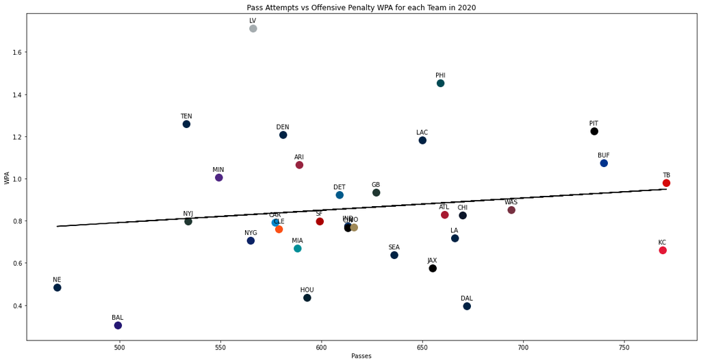

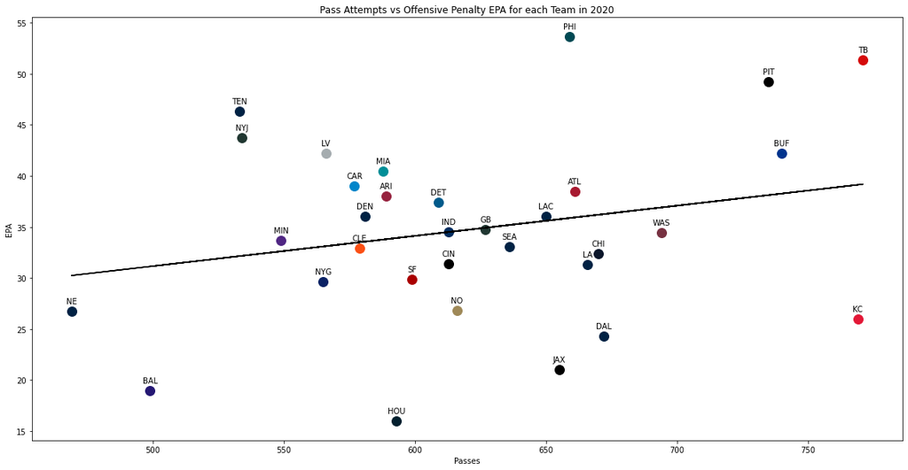

```python
#getting only penalties on offensive plays
wpa_off = {}
epa_off = {}
for index, row in pen_noplay_df.iterrows():
    if row['penalty_team'] == row['home_team']:
        ben_team = row['away_team']
    else:
        ben_team = row['home_team']

    if row['posteam'] == ben_team and str(row['wpa']) != 'nan' and str(row['epa']) != 'nan':
        if ben_team in wpa_off:
            wpa_off[ben_team] +=  row['wpa']
        else:
            wpa_off[ben_team] =  row['wpa']

        if ben_team in epa_off:
            epa_off[ben_team] +=  row['epa']
        else:
            epa_off[ben_team] =  row['epa']

#graphing pass attempts vs offensive penalty wpa for each team, with regression line
lm = linear_model.LinearRegression()
arr_x_vals = []
arr_y_vals = []
plt.figure(figsize=(20,10))
plt.xlabel("Passes")
plt.ylabel("WPA")
plt.title("Pass Attempts vs Offensive Penalty WPA for each Team in 2020")
for team,wpa_val in wpa_off.items():
    plt.plot(passes[team], wpa_val, color=team_colors_map[team], marker='o',markersize=12)
    plt.annotate(team, (passes[team], wpa_val), textcoords="offset points", xytext=(0,10), ha='center')
    arr_x_vals.append(passes[team])
    arr_y_vals.append(wpa_val)
arr_x_vals = np.array(arr_x_vals)
arr_y_vals = np.array(arr_y_vals)
lm.fit(arr_x_vals.reshape(-1,1), arr_y_vals.reshape(-1,1))
y_pred = lm.predict(arr_x_vals.reshape(-1,1))
plt.plot(arr_x_vals, y_pred, '-', color='black')
plt.show()

#graphing pass attempts vs offensive penalty epa for each team, with regression line
lm = linear_model.LinearRegression()
arr_x_vals = []
arr_y_vals = []
plt.figure(figsize=(20,10))
plt.xlabel("Passes")
plt.ylabel("EPA")
plt.title("Pass Attempts vs Offensive Penalty EPA for each Team in 2020")
for team,epa_val in epa_off.items():
    plt.plot(passes[team], epa_val, color=team_colors_map[team], marker='o',markersize=12)
    plt.annotate(team, (passes[team], epa_val), textcoords="offset points", xytext=(0,10), ha='center')
    arr_x_vals.append(passes[team])
    arr_y_vals.append(epa_val)
arr_x_vals = np.array(arr_x_vals)
arr_y_vals = np.array(arr_y_vals)
lm.fit(arr_x_vals.reshape(-1,1), arr_y_vals.reshape(-1,1))
y_pred = lm.predict(arr_x_vals.reshape(-1,1))
plt.plot(arr_x_vals, y_pred, '-', color='black')
plt.show()
```

In my opinion there is no strong correlation here, though the second graph (Pass Attempts vs Offensive Penalty EPA) is maybe one of the closest we've gotten so far. One last thing we can try is considering the quality of a passing offense instead of just the number of attempts. To measure the quality of passing offense I (in one of the earlier cells) created a dict called passing_epa_per_play which is simply the passing EPA accumulated by each team over the course of the season divided by the number of passing attempts. Maybe teams that are good at passing get penalty help?

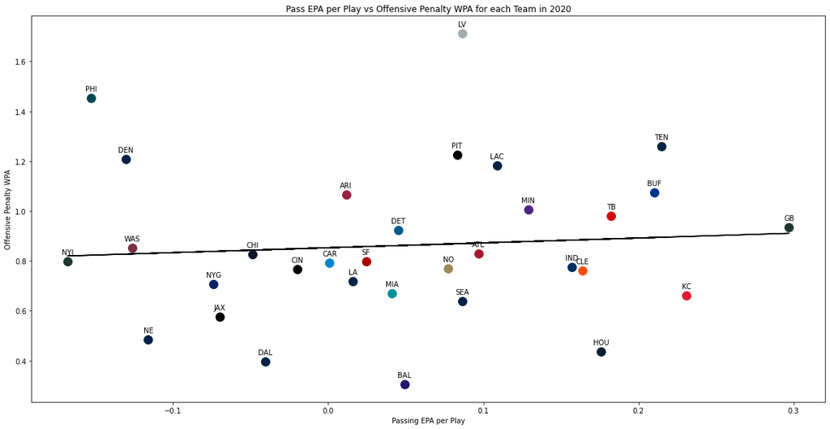

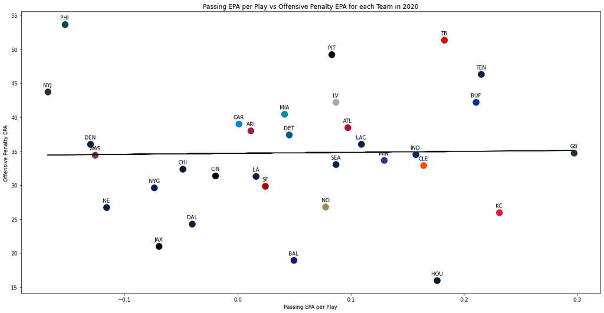

```python
#graphing pass epa/play vs offensive penalty wpa for each team, with regression line
lm = linear_model.LinearRegression()
arr_x_vals = []
arr_y_vals = []
plt.figure(figsize=(20,10))
plt.xlabel("Passing EPA per Play")
plt.ylabel("Offensive Penalty WPA")
plt.title("Pass EPA per Play vs Offensive Penalty WPA for each Team in 2020")
for team,wpa_val in wpa_off.items():
    plt.plot(passing_epa_per_play[team], wpa_val, color=team_colors_map[team], marker='o',markersize=12)
    plt.annotate(team, (passing_epa_per_play[team], wpa_val), textcoords="offset points", xytext=(0,10), ha='center')
    arr_x_vals.append(passing_epa_per_play[team])
    arr_y_vals.append(wpa_val)
arr_x_vals = np.array(arr_x_vals)
arr_y_vals = np.array(arr_y_vals)
lm.fit(arr_x_vals.reshape(-1,1), arr_y_vals.reshape(-1,1))
y_pred = lm.predict(arr_x_vals.reshape(-1,1))
plt.plot(arr_x_vals, y_pred, '-', color='black')
plt.show()

#graphing pass epa/play vs offensvie penalty epa for each team, with regression line
lm = linear_model.LinearRegression()
arr_x_vals = []
arr_y_vals = []
plt.figure(figsize=(20,10))
plt.xlabel("Passing EPA per Play")
plt.ylabel("Offensive Penalty EPA")
plt.title("Passing EPA per Play vs Offensive Penalty EPA for each Team in 2020")
for team,epa_val in epa_off.items():
    plt.plot(passing_epa_per_play[team], epa_val, color=team_colors_map[team], marker='o',markersize=12)
    plt.annotate(team, (passing_epa_per_play[team], epa_val), textcoords="offset points", xytext=(0,10), ha='center')
    arr_x_vals.append(passing_epa_per_play[team])
    arr_y_vals.append(epa_val)
arr_x_vals = np.array(arr_x_vals)
arr_y_vals = np.array(arr_y_vals)
lm.fit(arr_x_vals.reshape(-1,1), arr_y_vals.reshape(-1,1))
y_pred = lm.predict(arr_x_vals.reshape(-1,1))
plt.plot(arr_x_vals, y_pred, '-', color='black')
plt.show()
```

Nope, still no correlation.

## Conclusion

So it seems that penalties, while certainly important and impactful, maybe are not indicative of other aspects of games. In this analysis I asked two questions: (1) Is there any correlation between a team being good and penalties being favorable to them? (2) Do pass-heavy offenses get helped by penalties more? We found that the answer to both these questions are no, or at least that we can't say that they are based on the data we looked at.

I was definitely suprised by these results, but maybe that says more about the biases that I've formed from watching the sport. If I had more time with this project I would definitely try to find the answers to a few more questions that I've always had. For example, is there a discernable difference between the penalty impacts when at home and when away? Are there certain types of penalties that good teams avoid and that bad teams take more of? What types of penalties are the most damaging and what types are the most insignificant? These are all questions that I think would be interesting to look into.

Thank you for viewing this project! I hope you learned something new, because I definitely did!